# 贝叶斯第四章

我们知道，在一定程度上，平均身高随着平均体重的增加而增加。我们试着把$\beta$限制在正值。最简单的方法是把先验定义为对数正态。
$$\beta\sim Log-Normal(0,1)$$

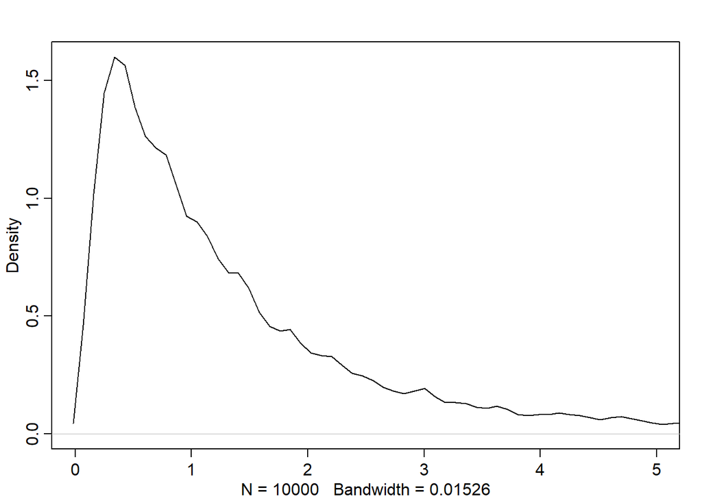

```r
#对数正态的随机数
b <- rlnorm( 10000 , 0 , 1 )
dens( b , xlim=c(0,5) , adj=0.1 )
```

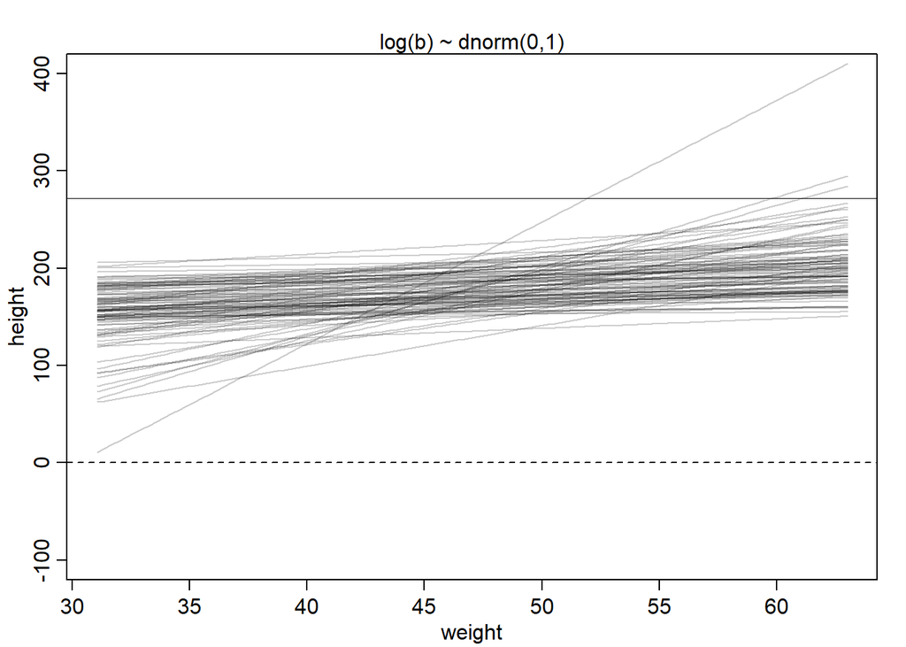

```r
set.seed(2971)
N <- 100 # 100 lines
a <- rnorm( N , 178 , 20 )
b <- rlnorm( N , 0 , 1 )

plot( NULL , xlim=range(d2$weight) , ylim=c(-100,400) ,
      xlab="weight" , ylab="height" )
abline( h=0 , lty=2 ) #h画水平线，=后是截距；lty是线条类型
abline( h=272 , lty=1 , lwd=0.5 ) #lwd是线条宽度
mtext( "log(b) ~ dnorm(0,1)" ) #指定文字出现的位置
xbar <- mean(d2$weight) #体重的平均值
#绘制图像
for ( i in 1:N ) curve( a[i] + b[i]*(x - xbar) ,
                        from=min(d2$weight) , to=max(d2$weight) ,
                        add=TRUE,col=col.alpha("black",0.2) )
```

在后面的章节中可以看到因为该样本数据足够多，先验信息可能并不是很重要，但不是所有样本的数据都足够多，在样本数据量较少的情况下进行先验信息的可视化验证很重要。

**4.4.2 寻找后验分布**

我们所要做的就是将新的平均数模型纳入quap的模型中，并为新的参数β添加一个先验。重复一下模型的定义：

$$h_i\sim Normal(\mu_i,\sigma),(height\sim
dnorm(mu,sigma))$$

$$\mu_i = \alpha + \beta(x_i - \bar x),(mu
<- a+b*(weight-xbar))$$

$$\alpha\sim Normal(178,20),(a\sim
dnorm(178,20))$$

$$\sigma\sim Uniform(0,50),(\sigma\sim
dunif(0,50))$$

```r
#载入数据
library(rethinking)
data(Howell1)
d <- Howell1
d2 <- d[ d$age >= 18 , ]
#定义体重的平均数x-bar
xbar <- mean(d2$weight)
# fit model
m4.3 <- quap(
  alist(
    height ~ dnorm( mu , sigma ) ,
    mu <- a + b*( weight - xbar ) ,
    a ~ dnorm( 178 , 20 ) ,
    b ~ dlnorm( 0 , 1 ) ,
    sigma ~ dunif( 0 , 50 )
    ) , data=d2 )
```

**4.4.3 解释后验分布**

```r
precis( m4.3 )
```

```
##              mean         sd        5.5%       94.5%
## a     154.6013671 0.27030766 154.1693633 155.0333710
## b       0.9032807 0.04192363   0.8362787   0.9702828
## sigma   5.0718809 0.19115478   4.7663786   5.3773831
```

**让我们把重点放在b (β)上，因为它是一个新参数**：

- 由于β是一个斜率，数值0.90可以理解为体重增加1公斤，身高期望预计会高0.90厘米。
- 89%的后验概率位于0.84和0.97之间。这表明β值接近于零或大于1与这个模型不兼容。
- 这个结果当然不是证明体重和身高之间的关系是线性的，因为这个模型只考虑他们之间的线性性。它只是说明如果你认为身高和体重的关系是线性的，那么斜率在0.9左右是可信的。

我们将从原始数据和一条拟合线开始。下面的代码绘制了原始数据，计算了a和b的后验平均值和拟合直线。

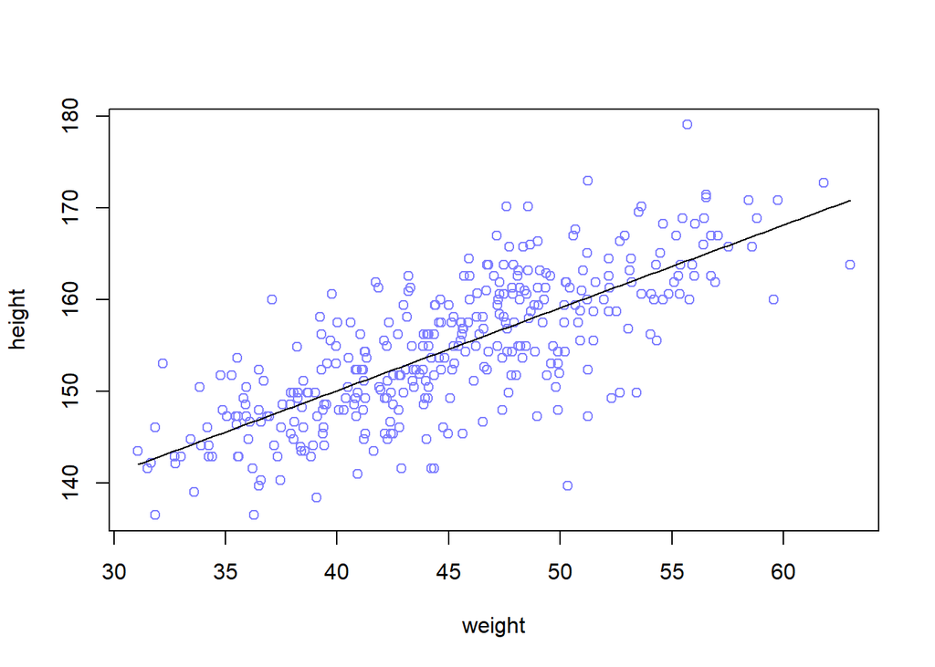

```r
#以厘米为单位的身高（垂直）与以公斤为单位的体重（水平）相比较，后验平均线以黑色标出。
plot( height ~ weight , data=d2 , col=rangi2 )
post <- extract.samples( m4.3 )
a_map <- mean(post$a)
b_map <- mean(post$b)
curve( a_map + b_map*(x - xbar) , add=TRUE )
```

**增加平均值的不确定性：**

- 后验平均线只是后验分布所考虑的无数条线中最合理的一条。像上图这样的平均线图，对于了解一个变量的估计影响的大小是很有用的，但它们对不确定性的表现很差。

**那么，我们怎样才能把这个不确定因素放到图上呢？**

- α和β的组合一起定义了一条线。因此，我们可以从后验分布中抽出**一堆线**。然后我们可以在图上显示这些线，以可视化回归关系中的不确定性。

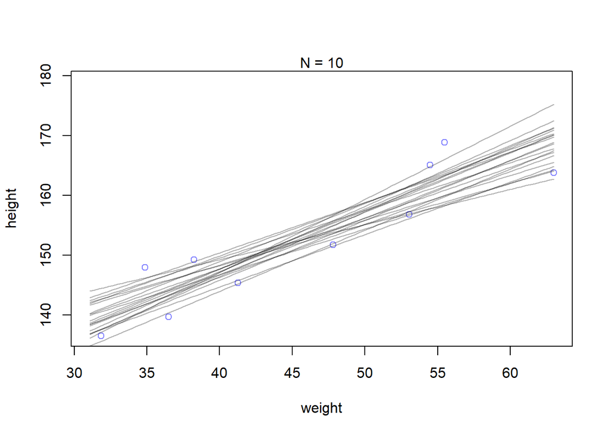

```r
#取前十个样本进行二次逼近，得到后验分布mN
N <- 10
dN <- d2[ 1:N , ]
mN <- quap(
  alist(height ~ dnorm( mu , sigma ) ,
        mu <- a + b*( weight - mean(weight) ) ,
        a ~ dnorm( 178 , 20 ) ,
        b ~ dlnorm( 0 , 1 ) ,
        sigma ~ dunif( 0 , 50 )
        ) , data=dN )

#展示20条线来查看其不确定性
post <- extract.samples(mN, n=20)
# 展示原始数据和抽取的样本个数
plot( dN$weight , dN$height ,
      xlim=range(d2$weight) , ylim=range(d2$height) ,
      col=rangi2 , xlab="weight" , ylab="height" )
mtext(concat("N = ",N))
#展示20个a,b的不同组合，用for循环进行
for ( i in 1:20 )
  curve( post$a[i] + post$b[i]*(x-mean(dN$weight)) ,
         col=col.alpha("black",0.3) , add=TRUE )
```

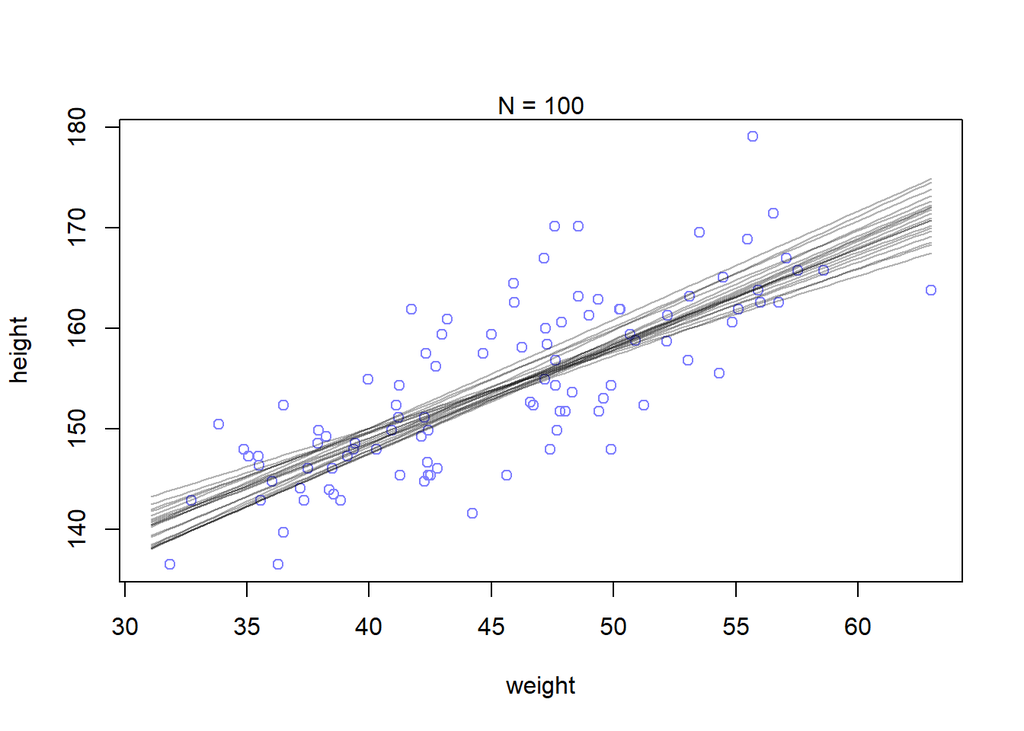

```r
#尾部的不确定性更大

N <- 100
dN <- d2[ 1:N , ]
mN <- quap(
  alist(height ~ dnorm( mu , sigma ) ,
        mu <- a + b*( weight - mean(weight) ) ,
        a ~ dnorm( 178 , 20 ) ,
        b ~ dlnorm( 0 , 1 ) ,
        sigma ~ dunif( 0 , 50 )
        ) , data=dN )

#展示20条线来查看其不确定性
post <- extract.samples(mN, n=20)
# 展示原始数据和抽取的样本个数
plot( dN$weight , dN$height ,
      xlim=range(d2$weight) , ylim=range(d2$height) ,
      col=rangi2 , xlab="weight" , ylab="height" )
mtext(concat("N = ",N))
#展示20个a,b的不同组合，用for循环进行
for ( i in 1:20 )
  curve( post$a[i] + post$b[i]*(x-mean(dN$weight)) ,
         col=col.alpha("black",0.3) , add=TRUE )
```

```r
#随着样本量的增加，回归线图变得更加紧凑。这是模型对平均值的位置越来越有信心的结果。
```

**绘制回归区间和等值线**

我们暂时把注意力集中在一个单一的体重值上，比如50公斤。可以通过使用后验分布样本，迅速为一个体重为50公斤的人列出10000个μ值。

```r
post <- extract.samples( m4.3 )
mu_at_50 <- post$a + post$b * (50 - xbar)
```

由于a和b的联合计算，这些平均值的变化包含了两个参数的不确定性和相关性。在这一点上，实际绘制这个平均数向量的密度可能会有帮助：

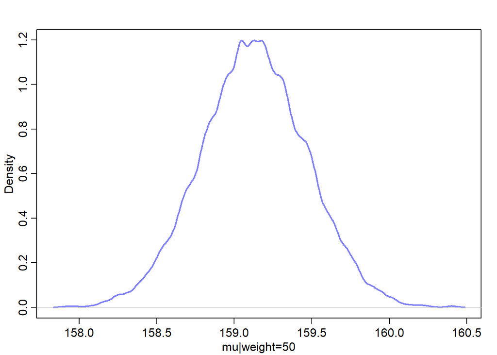

```r
dens( mu_at_50 , col=rangi2 , lwd=2 , xlab="mu|weight=50" )
```

```r
#兼容区间
PI( mu_at_50 , prob=0.89 )
```

```
##       5%      94%
## 158.5790 159.6752
```

我们需要对线性图示上横轴上的每一个重量值重复上述计算，并在平均斜率周围画出89%的区间。

```r
#一般默认是从二次逼近后验分布中抽取1000个样本
#(link在这里可以理解成特殊的后验分布抽样)
#post <- extract.samples(m4.3)
#mu.link <- function(weight) post$a + post$b*( weight - xbar )
#weight.seq <- seq( from=25 , to=70 , by=1 )
#mu <- sapply( weight.seq , mu.link ),sapply一次性对一堆数据执行某个函数
mu <- link( m4.3 )
str(mu) #紧凑的显示对象内部结构
```

```
##  num [1:1000, 1:352] 157 157 157 157 157 ...
```

上面我们有一个原始数据中每个人身高的µ分布。但实际上，我们想要的东西略有不同：我们想要线性模型横轴上每个体重值对应身高的µ分布。

```r
#将横轴的体重数据分成间距为1的数据
weight.seq <- seq( from=25 , to=70 , by=1 )
mu <- link( m4.3 , data=data.frame(weight=weight.seq) )
str(mu)
```

```
##  num [1:1000, 1:46] 136 138 136 136 137 ...
```

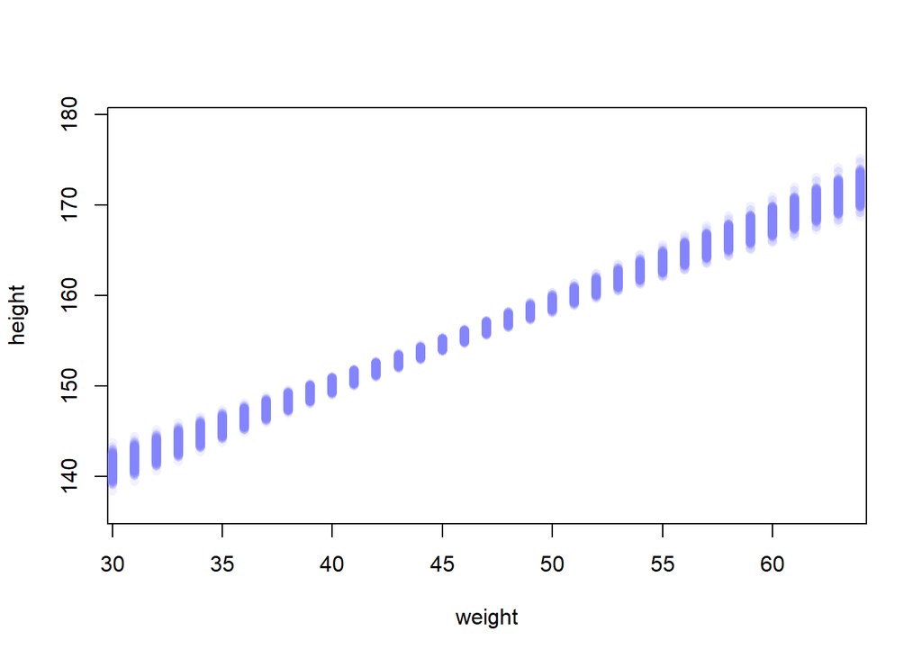

```r
#可视化
#按照d2数据设定图像横纵坐标并隐藏原始数据
plot( height ~ weight , d2 , type="n" ) #type=n，隐藏原始数据

#循环处理样本，并绘制每个mu值
for ( i in 1:1000 )
points( weight.seq , mu[i,] , pch=16 , col=col.alpha(rangi2,0.1) )
```

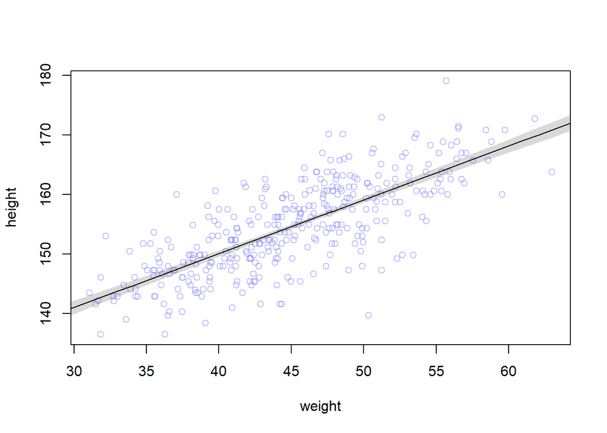

```r
#对每个体重值的分布进行总结。我们将使用apply，它可以将选择的函数应用于一个矩阵。
mu.mean <- apply( mu , 2 , mean )  #算每一列mu的均值;1代表计算行,2代表计算列
mu.PI <- apply( mu , 2 , PI , prob=0.89 ) #mu的89%区间

#把原始数据显示出来
plot( height ~ weight , data=d2 , col=col.alpha(rangi2,0.5) )

#画出最优拟合线
lines( weight.seq , mu.mean )

#89%的区间
shade( mu.PI , weight.seq )
```

**89%的预测区间（区别置信区间）**

最开始对于$h_i$的统计模型如下：
$$h_i\sim
Normal(\mu_i,\sigma)$$
到目前为止，我们所做的只是用后验的样本来可视化μi的不确定性，即平均值的线性模型。但是对高度的实际预测也取决于σ，所有这些都表明我们需要以某种方式将σ纳入预测中。

```r
#从后验分布中取包含了sigma的身高值可以采用sim
sim.height <- sim( m4.3 , data=list(weight=weight.seq) )
str(sim.height)
```

```
##  num [1:1000, 1:46] 135 136 145 146 140 ...
```

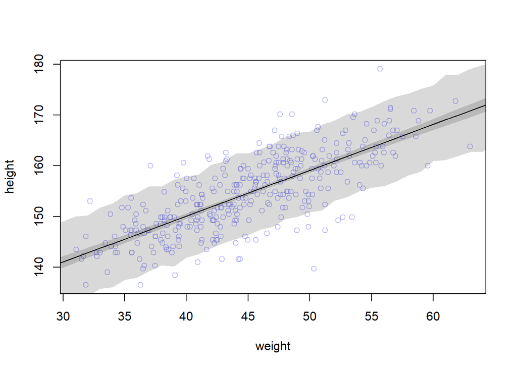

```r
#他跟前面的mu很像，但他加入了不确定性
#post <- extract.samples(m4.3)
#weight.seq <- 25:70
#sim.height <- sapply( weight.seq , function(weight)
#rnorm(
#n=nrow(post) ,
#mean=post$a + post$b*( weight - xbar ) ,
#sd=post$sigma ) )

#同样我们可以用apply及图像画出来它的样子

height.PI <- apply( sim.height , 2 , PI , prob=0.89 )
plot( height ~ weight , d2 , col=col.alpha(rangi2,0.5) )
lines( weight.seq , mu.mean )
shade( mu.PI , weight.seq )
shade( height.PI , weight.seq )
```

注意到宽阴影区间的轮廓有点粗糙，这是高斯分布尾部大方差导致的。可以增加后验分布中抽取的样本数使其更平滑。sim.height的可选参数n可以控制使用多少个样本。

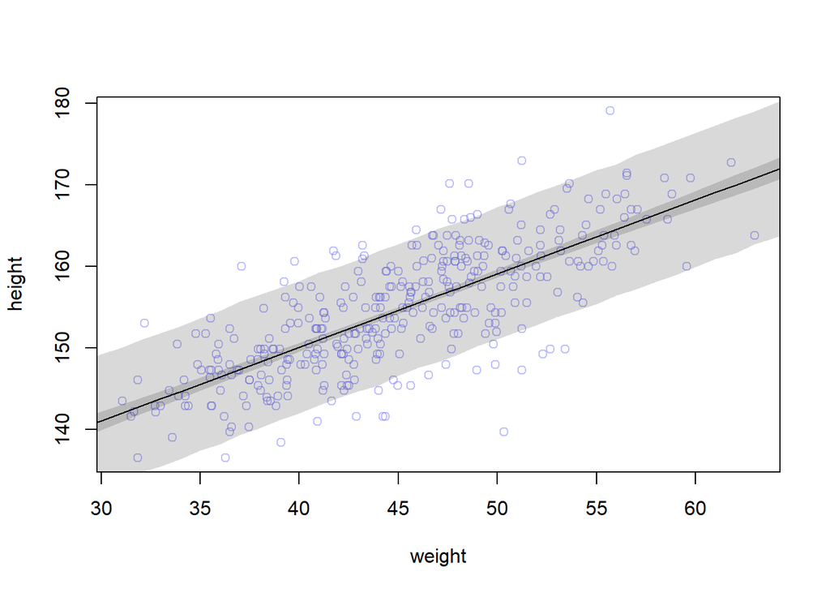

```r
sim.height1 <- sim( m4.3 , data=list(weight=weight.seq) , n=10000 )
height.PI1 <- apply( sim.height1 , 2 , PI , prob=0.89 )

plot( height ~ weight , d2 , col=col.alpha(rangi2,0.5) )
lines( weight.seq , mu.mean )
shade( mu.PI , weight.seq )
shade( height.PI1 , weight.seq )
```